# Engle-Granger Analysis of NYMEX Petroleum Futures Data

Tyler J. Brough

April 5, 2018

## Introduction

We will examine the NYMEX futures data for petroleum contracts, specifically the ones for WTI Crude Oil and New York Harbour Heating Oil.

To match the Alizadeh & Nomikos analysis we will use the weekly data from August 1989 to September 20, 2006.

*NB:* In the video I pulled daily data and worked with the full time series. This represents an update to that analysis.

## Data Analysis

Let’s first import the packages we will need to work with.

```r
library(urca)
library(tseries)
library(zoo)
```

We will now read in the data, fix the date formatting, and create `zoo` time series objects.

NB: Alizadeh et al refer to the WTI crude oil series as `CL` and to the heating oil series as `HO`, so we will adopt this naming convention as well.

```r
# Set the working directory
setwd("/home/brough/USU/Teaching/Spring2018/repos/Fin6320/assignments/Final Project")

# Read in the raw data series with headers
raw.cl <- read.csv("EIA NYMEX Futures Data - Cushing OK Contract 1 Weekly (WTI Crude Oil).csv", header=TRUE)
head(raw.cl)
```

```
##         Date Value
## 1 2018-03-30 65.03
## 2 2018-03-23 64.16
## 3 2018-03-16 61.31
## 4 2018-03-09 61.70
## 5 2018-03-02 62.16
## 6 2018-02-23 62.32
```

```r
tail(raw.cl)
```

```
##            Date Value
## 1821 1983-05-13 29.98
## 1822 1983-05-06 30.44
## 1823 1983-04-29 30.74
## 1824 1983-04-22 30.73
## 1825 1983-04-15 30.61
## 1826 1983-04-08 29.92
```

```r
raw.ho <- read.csv("EIA NYMEX Futures Data - Heating Oil Contract 1 Weekly (NYMEX Heating Oil).csv", header=TRUE)
head(raw.ho)
```

```
##         Date Value
## 1 2018-03-30 2.020
## 2 2018-03-23 1.974
## 3 2018-03-16 1.886
## 4 2018-03-09 1.884
## 5 2018-03-02 1.926
## 6 2018-02-23 1.939
```

```r
tail(raw.ho)
```

```
##            Date Value
## 1991 1980-02-08 0.786
## 1992 1980-02-01 0.776
## 1993 1980-01-25 0.746
## 1994 1980-01-18 0.739
## 1995 1980-01-11 0.796
## 1996 1980-01-04 0.833
```

```r
# Transform heating oil prices to $/bbl (with 42 gallons per barrel)
raw.ho$Value <- 42 * raw.ho$Value
```

Now that we have the raw data read in, let’s fix the date formatting.

```r
# Change the date formatting for CL and HO
raw.cl$Date <- as.Date(raw.cl$Date, format="%Y-%m-%d")
raw.ho$Date <- as.Date(raw.ho$Date, format="%Y-%m-%d")

# Create zoo time series objects
cl <- zoo(log(raw.cl$Value), raw.cl$Date)
ho <- zoo(log(raw.ho$Value), raw.ho$Date)
petro.full <- merge(cl, ho, all=FALSE)

# Now subset the data from 08/01/1989 to 09/20/2006 (should be 894 observations)
ind <- (index(petro.full) >= as.Date("1989-08-01") & index(petro.full) <= as.Date("2006-09-20"))
petro.sub <- petro.full[ind]
length(petro.sub$cl)
```

```
## [1] 894
```

```r
length(petro.sub$ho)
```

```
## [1] 894
```

Let’s make a joint plot of the data for visual inspection.

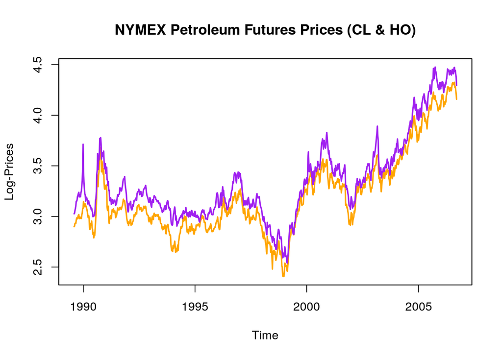

```r
plot(petro.sub, screens=1, lwd=2, type="l", col=c("orange", "purple"),
     main="NYMEX Petroleum Futures Prices (CL & HO)",
     xlab="Time", ylab="Log-Prices")
```

It’s pretty easy to see the cointegration visually!

### ADF Tests for Stationarity

#### ADF Tests in Log-Prices

Now let’s use the ADF test to test for stationarity in the log-prices of CL and HO.

```r
adf.cl <- ur.df(petro.sub$cl, type = "none", selectlags = "BIC")
summary(adf.cl)
```

```
##
## ###############################################
## # Augmented Dickey-Fuller Test Unit Root Test #
## ###############################################
##
## Test regression none
##
##
## Call:
## lm(formula = z.diff ~ z.lag.1 - 1 + z.diff.lag)
##
## Residuals:
##       Min        1Q    Median        3Q       Max
## -0.188989 -0.022615  0.000932  0.024356  0.189644
##
## Coefficients:
##             Estimate Std. Error t value Pr(>|t|)
## z.lag.1    0.0003394  0.0004181   0.812  0.41715
## z.diff.lag 0.0988576  0.0334064   2.959  0.00317 **
## ---
## Signif. codes:  0 '***' 0.001 '**' 0.01 '*' 0.05 '.' 0.1 ' ' 1
##
## Residual standard error: 0.04032 on 890 degrees of freedom
## Multiple R-squared:  0.01074,    Adjusted R-squared:  0.008513
## F-statistic: 4.829 on 2 and 890 DF,  p-value: 0.008202
##
##
## Value of test-statistic is: 0.8118
##
## Critical values for test statistics:
##       1pct  5pct 10pct
## tau1 -2.58 -1.95 -1.62
```

We can see that for CL we fail to reject the null hypothesis of unit-root non-stationarity.

```r
adf.ho <- ur.df(petro.sub$ho, type = "none", selectlags = "BIC")
summary(adf.ho)
```

```
##
## ###############################################
## # Augmented Dickey-Fuller Test Unit Root Test #
## ###############################################
##
## Test regression none
##
##
## Call:
## lm(formula = z.diff ~ z.lag.1 - 1 + z.diff.lag)
##
## Residuals:
##       Min        1Q    Median        3Q       Max
## -0.301364 -0.024729  0.004086  0.023260  0.216241
##
## Coefficients:
##             Estimate Std. Error t value Pr(>|t|)
## z.lag.1    0.0003081  0.0004240   0.727 0.467559
## z.diff.lag 0.1125809  0.0333971   3.371 0.000781 ***
## ---
## Signif. codes:  0 '***' 0.001 '**' 0.01 '*' 0.05 '.' 0.1 ' ' 1
##
## Residual standard error: 0.04276 on 890 degrees of freedom
## Multiple R-squared:  0.01345,    Adjusted R-squared:  0.01124
## F-statistic: 6.068 on 2 and 890 DF,  p-value: 0.002412
##
##
## Value of test-statistic is: 0.7268
##
## Critical values for test statistics:
##       1pct  5pct 10pct
## tau1 -2.58 -1.95 -1.62
```

We can also see that for HO we fail to reject the null hypothesis of unit-root non-stationarity. So far we have that both CL and HO contain unit roots.

#### ADF Tests in Log-Returns

Now let’s use the ADF test to test for stationarity in the log-returns of CL and HO.

```r
adf.ret.cl <- ur.df(diff(petro.sub$cl), type = "none", selectlags = "BIC")
summary(adf.ret.cl)
```

```
##
## ###############################################
## # Augmented Dickey-Fuller Test Unit Root Test #
## ###############################################
##
## Test regression none
##
##
## Call:
## lm(formula = z.diff ~ z.lag.1 - 1 + z.diff.lag)
##
## Residuals:
##       Min        1Q    Median        3Q       Max
## -0.187335 -0.021746  0.002258  0.025989  0.193694
##
## Coefficients:
##            Estimate Std. Error t value Pr(>|t|)
## z.lag.1    -0.94142    0.04502 -20.913   <2e-16 ***
## z.diff.lag  0.04599    0.03354   1.371    0.171
## ---
## Signif. codes:  0 '***' 0.001 '**' 0.01 '*' 0.05 '.' 0.1 ' ' 1
##
## Residual standard error: 0.04031 on 889 degrees of freedom
## Multiple R-squared:  0.4508, Adjusted R-squared:  0.4496
## F-statistic: 364.9 on 2 and 889 DF,  p-value: < 2.2e-16
##
##
## Value of test-statistic is: -20.913
##
## Critical values for test statistics:
##       1pct  5pct 10pct
## tau1 -2.58 -1.95 -1.62
```

After having taken log-price first differences (i.e. log-returns), we now strongly reject the null hypothesis of a unit root. We conclude that CL log-returns are weakly stationary.

```r
adf.ret.ho <- ur.df(diff(petro.sub$ho), type = "none", selectlags = "BIC")
summary(adf.ret.ho)
```

```
##
## ###############################################
## # Augmented Dickey-Fuller Test Unit Root Test #
## ###############################################
##
## Test regression none
##
##
## Call:
## lm(formula = z.diff ~ z.lag.1 - 1 + z.diff.lag)
##
## Residuals:
##       Min        1Q    Median        3Q       Max
## -0.293982 -0.023468  0.004351  0.024495  0.219291
##
## Coefficients:
##            Estimate Std. Error t value Pr(>|t|)
## z.lag.1    -0.94193    0.04469 -21.076   <2e-16 ***
## z.diff.lag  0.06251    0.03354   1.864   0.0627 .
## ---
## Signif. codes:  0 '***' 0.001 '**' 0.01 '*' 0.05 '.' 0.1 ' ' 1
##
## Residual standard error: 0.04271 on 889 degrees of freedom
## Multiple R-squared:  0.4444, Adjusted R-squared:  0.4432
## F-statistic: 355.6 on 2 and 889 DF,  p-value: < 2.2e-16
##
##
## Value of test-statistic is: -21.0764
##
## Critical values for test statistics:
##       1pct  5pct 10pct
## tau1 -2.58 -1.95 -1.62
```

Same for HO! We can now conduct the first step of the Engle-Granger method.

### The Engle-Granger Test for Cointegration

```r
fit <- lm(petro.sub$ho ~ petro.sub$cl)
z <- fit$residuals
adf.z <- ur.df(z, type = "none", selectlags = "BIC")
summary(adf.z)
```

```
##
## ###############################################
## # Augmented Dickey-Fuller Test Unit Root Test #
## ###############################################
##
## Test regression none
##
##
## Call:
## lm(formula = z.diff ~ z.lag.1 - 1 + z.diff.lag)
##
## Residuals:
##       Min        1Q    Median        3Q       Max
## -0.285146 -0.011980  0.000404  0.013549  0.260104
##
## Coefficients:
##             Estimate Std. Error t value Pr(>|t|)
## z.lag.1    -0.120168   0.016364  -7.344  4.7e-13 ***
## z.diff.lag  0.007999   0.033536   0.239    0.812
## ---
## Signif. codes:  0 '***' 0.001 '**' 0.01 '*' 0.05 '.' 0.1 ' ' 1
##
## Residual standard error: 0.02981 on 890 degrees of freedom
## Multiple R-squared:  0.05968,    Adjusted R-squared:  0.05757
## F-statistic: 28.25 on 2 and 890 DF,  p-value: 1.278e-12
##
##
## Value of test-statistic is: -7.3435
##
## Critical values for test statistics:
##       1pct  5pct 10pct
## tau1 -2.58 -1.95 -1.62
```

We quite strongly reject the null hypothesis that the residuals from the cointegrating regression of HO on CL contains a unit root. We therefore conclude that HO and CL are cointegrated. This allows us to proceed to the next step and fit the Vector Error Correction Model (VECM) for HO and CL. We will do this in another document. See you then!